# Clean phenotypes: wecare feb2016

Alexey Larionov

started: 01Mar2016 last updated: 11Dec2016

# Summary

This step prepares phenotype data for downstream analysis. It selects and merges data from various, partially duplicated and incomplete source files: covar, demographics, samples and phenotypes_update.

The data selection is based on the prior data assessment done during previous versions of analysis (feb, aug, sep 2016).

# start_section

```r
# Start time
Sys.time()
```

```
## [1] "2016-12-11 20:46:06 GMT"
```

```r
# Do NOT clean-up at this stage
#rm(list=ls()) # this would remove params object!
graphics.off()

# Read parameters
interim_data_folder <- params$interim_data

# Required libraries
library(dplyr) # for piping, filter, select etc
library(reshape2) # for melt()
library(ggplot2)

# Set root working folder
#library(knitr)
#opts_knit$set(root.dir = "/scratch/medgen/scripts/wecare_stat_11.16/scripts")
#setwd("/scratch/medgen/scripts/wecare_stat_11.16/scripts")
```

# load_data

```r
# Remove params object to avoid interference with load() function
rm(params)

load(paste(interim_data_folder, "s02_filter_genotypes.RData", sep="/"))
```

# check_data

```r
ls()
```

```
##  [1] "covar.df"             "demographics.df"      "dp.mx"
##  [4] "exac.df"              "gq.mx"                "gt.mx"
##  [7] "interim_data_folder"  "kgen.df"              "params"
## [10] "phenotypes_update.df" "samples.df"           "vv.df"
```

```r
dim(covar.df)
```

```
## [1] 498  34
```

```r
str(covar.df)
```

```
## 'data.frame':    498 obs. of  34 variables:
##  $ Subject_ID      : int  200054 200491 200565 200698 200958 201046 201558 201921 202026 202236 ...
##  $ setno           : int  382125 204356 360683 226881 357431 374980 201558 201921 213991 385058 ...
##  $ cc              : int  0 0 0 0 0 0 1 1 0 0 ...
##  $ chemo           : int  1 1 0 0 1 1 1 1 1 1 ...
##  $ hormone         : int  0 1 1 0 1 0 0 1 1 0 ...
##  $ chemo_hormone   : Factor w/ 5 levels "","both","chem",..: 3 2 4 5 2 3 3 2 2 3 ...
##  $ chemo_self_mra  : int  1 1 0 0 1 1 1 1 1 1 ...
##  $ hormone_self_mra: int  0 1 1 0 1 0 0 1 1 0 ...
##  $ treatment       : int  1 1 1 0 1 1 1 1 1 1 ...
##  $ ID              : int  2 6 7 9 11 12 16 22 24 26 ...
##  $ labid           : Factor w/ 498 levels "id200054","id200491",..: 1 2 3 4 5 6 7 8 9 10 ...
##  $ status          : int  0 0 0 0 0 0 1 1 0 0 ...
##  $ status2         : int  0 0 0 0 0 0 1 1 0 0 ...
##  $ offset          : num  6.41 5.82 5.61 4.03 4.77 ...
```

[output cut: 20 more lines]

```r
covar.df[1:5,1:5]
```

```
##   Subject_ID  setno cc chemo hormone
## 1     200054 382125  0     1       0
## 2     200491 204356  0     1       1
## 3     200565 360683  0     0       1
## 4     200698 226881  0     0       0
## 5     200958 357431  0     1       1
```

```r
dim(demographics.df)
```

```
## [1] 505  91
```

```r
str(demographics.df)
```

```
## 'data.frame':    505 obs. of  91 variables:
##  $ Subject_ID            : Factor w/ 503 levels "200054","200491",..: 1 2 3 4 5 6 7 8 9 10 ...
##  $ ID.x                  : num  2 6 7 9 11 12 NA NA 24 26 ...
##  $ labid.x               : Factor w/ 498 levels "15582015","19212019",..: 6 7 8 9 10 11 NA NA 12 13 ...
##  $ Eigen_1.x             : num  -0.0079 -0.01062 -0.00539 -0.00906 -0.01094 ...
##  $ Eigen_2.x             : num  0.0055 0.00414 0.00302 0.00301 0.0023 ...
##  $ Eigen_3.x             : num  -0.02171 0.01254 0.00368 -0.00655 -0.01389 ...
##  $ Eigen_4.x             : num  0.00356 -0.00787 -0.01496 -0.01256 -0.00501 ...
##  $ Eigen_5.x             : num  0.00135 -0.0291 0.00391 0.01357 -0.00526 ...
##  $ Phase                 : num  1 1 1 1 1 1 NA NA 1 1 ...
##  $ setno.x               : num  382125 204356 360683 226881 357431 ...
##  $ cc.x                  : int  0 0 0 0 0 0 NA NA 0 0 ...
##  $ rstime                : num  7.42 9.75 6.09 6.25 9.34 7 NA NA 6.09 8.66 ...
##  $ registry.x            : Factor w/ 7 levels "","de","IA","IR",..: 2 4 4 7 7 5 NA NA 3 2 ...
##  $ race.x                : num  0 0 0 0 0 0 NA NA 0 0 ...
```

[output cut: 77 more lines]

```r
demographics.df[1:5,1:5]
```

```
##   Subject_ID ID.x  labid.x    Eigen_1.x   Eigen_2.x
## 1     200054    2 id200054 -0.007897666 0.005498053
## 2     200491    6 id200491 -0.010615326 0.004141289
## 3     200565    7 id200565 -0.005393813 0.003017045
## 4     200698    9 id200698 -0.009061714 0.003010147
## 5     200958   11 id200958 -0.010936549 0.002295868
```

```r
dim(phenotypes_update.df)
```

```
## [1] 13 22
```

```r
str(phenotypes_update.df)
```

```
## 'data.frame':    13 obs. of  22 variables:
##  $ gwas_id       : chr  "id319270" "id298378" "id271981" "id301570" ...
##  $ wes_id        : chr  "P1_C02" "P1_C04" "P1_C06" "P1_C11" ...
##  $ cc            : int  0 0 0 0 1 0 1 1 0 0 ...
##  $ setno         : int  227587 243637 332699 247333 204830 204830 310424 247333 398607 201558 ...
##  $ family_history: int  1 1 1 0 1 0 1 1 0 0 ...
##  $ age_dx        : int  30 30 31 30 24 23 31 33 49 40 ...
##  $ age_ref       : int  39 33 32 34 28 27 32 37 54 47 ...
##  $ rstime        : num  9.08 3.17 2.09 4.5 3.83 3.83 1.33 4.5 5.16 7.25 ...
##  $ Eigen_1       : num  -0.01369 -0.00753 -0.00687 -0.00363 -0.01057 ...
##  $ Eigen_2       : num  0.00615 0.00853 0.00138 0.00428 0.00317 ...
##  $ Eigen_3       : num  -0.00474 -0.01256 0.00329 0.03749 -0.00716 ...
##  $ Eigen_4       : num  -0.00596 0.00849 -0.01233 -0.02952 -0.00024 ...
##  $ Eigen_5       : num  -0.01219 0.01074 -0.0138 -0.0202 -0.00147 ...
##  $ stage         : int  1 1 2 2 2 1 2 1 1 1 ...
##  $ er1           : num  0 1 0 1 0 1 1 NA 1 NA ...
##  $ pr1           : num  0 1 NA 1 0 1 0 NA 1 NA ...
##  $ hist_cat      : chr  "other carcinoma" "ductal" "ductal" "ductal" ...
##  $ hormone       : num  0 0 0 0 0 0 0 0 NA 0 ...
##  $ chemo_cat     : chr  "CMF" "no" "Oth" "no" ...
##  $ br_xray       : int  1 0 0 0 0 1 0 1 0 1 ...
##  $ br_xray_dose  : num  1.1 0 0 0 0 1.2 0 1.9 0 0.86 ...
##  $ num_preg      : int  2 0 1 1 1 0 0 1 1 0 ...
```

```r
phenotypes_update.df[1:5,1:5]
```

```
##    gwas_id wes_id cc  setno family_history
## 1 id319270 P1_C02  0 227587              1
## 2 id298378 P1_C04  0 243637              1
## 3 id271981 P1_C06  0 332699              1
## 4 id301570 P1_C11  0 247333              0
## 5 id204830 P1_E10  1 204830              1
```

```r
dim(samples.df)
```

```
## [1] 512   4
```

```r
str(samples.df)
```

```
## 'data.frame':    512 obs. of  4 variables:
##  $ wes_id   : Factor w/ 512 levels "P1_A01","P1_A02",..: 1 2 3 4 5 6 7 8 9 10 ...
##  $ gwas_id  : Factor w/ 510 levels "id200054","id200491",..: 14 405 315 264 67 121 326 251 281 141 ...
##  $ merged_id: Factor w/ 512 levels "P1_A01_id203568",..: 1 2 3 4 5 6 7 8 9 10 ...
##  $ filter   : Factor w/ 5 levels "duplicate","low_concordance",..: 5 5 5 5 5 5 5 5 5 5 ...
```

```r
samples.df[1:5,]
```

```
##   wes_id  gwas_id       merged_id filter
## 1 P1_A01 id203568 P1_A01_id203568   pass
## 2 P1_A02 id357807 P1_A02_id357807   pass
## 3 P1_A03 id325472 P1_A03_id325472   pass
## 4 P1_A04 id304354 P1_A04_id304354   pass
## 5 P1_A05 id222648 P1_A05_id222648   pass
```

```r
dim(vv.df)
```

```
## [1] 283651     35
```

```r
str(vv.df)
```

```
## 'data.frame':    283651 obs. of  35 variables:
##  $ SplitVarID         : Factor w/ 343824 levels "Var000000001",..: 2 8 9 12 13 20 21 22 23 24 ...
##  $ TYPE               : Factor w/ 2 levels "INDEL","SNP": 2 2 2 1 2 2 2 2 2 2 ...
##  $ ID                 : Factor w/ 253381 levels "rs10000804","rs10000924",..: 234676 162750 NA NA 180048 NA 60822 234680 179585 155441 ...
##  $ CHROM              : Factor w/ 25 levels "1","10","11",..: 1 1 1 1 1 1 1 1 1 1 ...
##  $ POS                : int  762330 871215 871230 874778 878664 880461 880483 880502 880917 881627 ...
##  $ REF                : Factor w/ 2142 levels "A","AAAAAAAAAAAAAAAAAAAAAAAG",..: 1044 539 539 1231 1044 539 1 539 1044 1044 ...
##  $ ALT                : Factor w/ 1297 levels "A","AAAAAAAAAAAAACT",..: 989 664 989 664 1 989 664 989 1 1 ...
##  $ QUAL               : num  7081 2492 237 16690 173 ...
##  $ DP                 : int  26720 16282 15415 15193 13636 21946 22167 21006 20632 24755 ...
##  $ AS_VQSLOD          : num  7.04 20.08 15.42 3.96 15.25 ...
##  $ FILTER             : Factor w/ 1 level "PASS": 1 1 1 1 1 1 1 1 1 1 ...
##  $ AC                 : int  8 5 1 58 1 1 8 1 1 891 ...
##  $ AF                 : num  0.006221 0.003811 0.000763 0.042 0.000709 ...
##  $ AN                 : int  1286 1312 1310 1390 1410 1368 1374 1376 1360 1412 ...
```

[output cut: 21 more lines]

```r
vv.df[1:5,1:5]
```

```
##                SplitVarID  TYPE          ID CHROM    POS
## Var000000002 Var000000002   SNP  rs74045217     1 762330
## Var000000008 Var000000008   SNP  rs28419423     1 871215
## Var000000009 Var000000009   SNP        <NA>     1 871230
## Var000000012 Var000000012 INDEL        <NA>     1 874778
## Var000000013 Var000000013   SNP rs370104927     1 878664
```

```r
dim(kgen.df)
```

```
## [1] 283651      9
```

```r
str(kgen.df)
```

```
## 'data.frame':    283651 obs. of  9 variables:
##  $ SplitVarID : Factor w/ 343824 levels "Var000000001",..: 2 8 9 12 13 20 21 22 23 24 ...
##  $ kgen.AC    : int  NA NA NA NA 2 NA 11 6 NA 2213 ...
##  $ kgen.AN    : int  NA NA NA NA 5008 NA 5008 5008 NA 5008 ...
##  $ kgen.AF    : num  NA NA NA NA 0.000399 ...
##  $ kgen.AFR_AF: num  NA NA NA NA 0 NA 0.0008 0.003 NA 0.0643 ...
##  $ kgen.AMR_AF: num  NA NA NA NA 0 NA 0.0043 0.0014 NA 0.438 ...
##  $ kgen.EAS_AF: num  NA NA NA NA 0 NA 0 0 NA 0.624 ...
##  $ kgen.EUR_AF: num  NA NA NA NA 0 ...
##  $ kgen.SAS_AF: num  NA NA NA NA 0.002 ...
```

```r
kgen.df[1:5,1:5]
```

```
##                SplitVarID kgen.AC kgen.AN     kgen.AF kgen.AFR_AF
## Var000000002 Var000000002      NA      NA          NA          NA
## Var000000008 Var000000008      NA      NA          NA          NA
## Var000000009 Var000000009      NA      NA          NA          NA
## Var000000012 Var000000012      NA      NA          NA          NA
## Var000000013 Var000000013       2    5008 0.000399361           0
```

```r
dim(exac.df)
```

```
## [1] 283651     48
```

```r
str(exac.df)
```

```
## 'data.frame':    283651 obs. of  48 variables:
##  $ SplitVarID             : Factor w/ 343824 levels "Var000000001",..: 2 8 9 12 13 20 21 22 23 24 ...
##  $ exac_non_TCGA.AF       : num  0.012 NA NA NA 0.000584 ...
##  $ exac_non_TCGA.AC       : int  175 NA NA NA 62 3 151 120 2 59637 ...
##  $ exac_non_TCGA.AN       : int  14012 NA NA NA 106198 106200 106186 106180 106210 106210 ...
##  $ exac_non_TCGA.AC_FEMALE: int  59 1553 NA NA 17 0 60 58 2 24874 ...
##  $ exac_non_TCGA.AN_FEMALE: int  3452 45840 NA NA 43050 44730 40654 33838 45832 45636 ...
##  $ exac_non_TCGA.AC_MALE  : int  91 1483 NA NA 45 3 91 60 0 34597 ...
##  $ exac_non_TCGA.AN_MALE  : int  8250 60304 NA NA 58126 59120 54094 45532 60288 60090 ...
##  $ exac_non_TCGA.AC_Adj   : int  150 3036 NA NA 62 3 151 118 2 59471 ...
##  $ exac_non_TCGA.AN_Adj   : int  11702 106144 NA NA 101176 103850 94748 79370 106120 105726 ...
##  $ exac_non_TCGA.AC_Hom   : int  0 136 NA NA 0 0 2 0 0 17732 ...
##  $ exac_non_TCGA.AC_Het   : int  150 2760 NA NA 62 3 147 118 2 24007 ...
##  $ exac_non_TCGA.AC_Hemi  : int  NA NA NA NA NA NA NA NA NA NA ...
##  $ exac_non_TCGA.AC_AFR   : int  85 263 NA NA 0 0 9 21 0 1225 ...
```

[output cut: 34 more lines]

```r
exac.df[1:5,1:5]
```

```
##                SplitVarID exac_non_TCGA.AF exac_non_TCGA.AC
## Var000000002 Var000000002        0.0120000              175
## Var000000008 Var000000008               NA               NA
## Var000000009 Var000000009               NA               NA
## Var000000012 Var000000012               NA               NA
## Var000000013 Var000000013        0.0005838               62
##              exac_non_TCGA.AN exac_non_TCGA.AC_FEMALE
## Var000000002            14012                      59
## Var000000008               NA                    1553
## Var000000009               NA                      NA
## Var000000012               NA                      NA
## Var000000013           106198                      17
```

```r
dim(gt.mx)
```

```
## [1] 283651    710
```

```r
class(gt.mx)
```

```
## [1] "matrix"
```

```r
gt.mx[10:25,1:5]
```

```
##              HG00097 HG00099 HG00100 HG00102 HG00106
## Var000000024       0       2       2       2       1
## Var000000025       0       0       0       0       0
## Var000000026       0       0       0       0       0
## Var000000027       0       0       0       0       0
## Var000000029       0       0       0       0       0
## Var000000030       0       0       0       0       0
## Var000000031       0       0       0       0       0
## Var000000037       0       0       0       0       0
## Var000000038       0       0       0       0       0
## Var000000039       0       0       0       0       0
## Var000000040       0       0      NA      NA       0
## Var000000041       0       0      NA       0      NA
## Var000000042      NA      NA      NA       0      NA
## Var000000043       0       0       0       0       0
## Var000000044       0       0       0       0       0
## Var000000045       0       0       0       0       1
```

```r
dim(gq.mx)
```

```
## [1] 283651    710
```

```r
class(gq.mx)
```

```
## [1] "matrix"
```

```r
gq.mx[10:25,1:5]
```

```
##              HG00097 HG00099 HG00100 HG00102 HG00106
## Var000000024      90      99      60      63      99
## Var000000025      99      99      36      57      99
## Var000000026      99      99      33      93      99
## Var000000027      99      99      60      69      99
## Var000000029      99      99      99      78      81
## Var000000030      99      99      99      99      99
## Var000000031      99      99      99      90      99
## Var000000037      99      65      60      72      62
## Var000000038      72      81      81      99      60
## Var000000039      72      81      81      99      99
## Var000000040      72      81      NA      18      72
## Var000000041      72      21      15      60      12
## Var000000042       3      18      15      60      15
## Var000000043      24      36      30      69      42
## Var000000044      72      90      36      81      66
## Var000000045      66      99      57      99      99
```

```r
dim(dp.mx)
```

```
## [1] 283651    710
```

```r
class(dp.mx)
```

```
## [1] "matrix"
```

```r
dp.mx[10:25,1:5]
```

```
##              HG00097 HG00099 HG00100 HG00102 HG00106
## Var000000024      34      92      20      21      51
## Var000000025      36      37      15      21      36
## Var000000026      36      37      13      34      36
## Var000000027      36      37      20      27      36
## Var000000029      39      39      34      29      29
## Var000000030      39      42      34      35      37
## Var000000031      39      42      34      32      41
## Var000000037      41      31      26      25      31
## Var000000038      26      29      35      39      22
## Var000000039      28      29      35      39      39
## Var000000040      25      29      NA       6      30
## Var000000041      25       7       5      21       4
## Var000000042       1       6       5      21       5
## Var000000043       8      12      10      26      14
## Var000000044      24      30      14      29      23
## Var000000045      29      34      20      34      42
```

```r
# Check consistence of rownames
sum(rownames(gt.mx) != rownames(gq.mx), na.rm=TRUE)
```

```
## [1] 0
```

```r
sum(rownames(gt.mx) != rownames(dp.mx), na.rm=TRUE)
```

```
## [1] 0
```

```r
sum(rownames(gt.mx) != rownames(vv.df), na.rm=TRUE)
```

```
## [1] 0
```

```r
sum(rownames(gt.mx) != rownames(kgen.df), na.rm=TRUE)
```

```
## [1] 0
```

```r
sum(rownames(gt.mx) != rownames(exac.df), na.rm=TRUE)
```

```
## [1] 0
```

# select_variants_annotations

Select variants annotations (based on the previous data assessments) This has nothing to do with phenotypes, but still needs to be done somewhere.

```r
variants.df <-
  vv.df %>%
  select(SplitVarID, SYMBOL, TYPE, CHROM, POS, REF, ALT, AC, AF, AN,
         Consequence, SIFT_call, SIFT_score, PolyPhen_call, PolyPhen_score, CLIN_SIG,
         cDNA_position, CDS_position, Codons, Protein_position, Amino_acids,
         Existing_variation, Multiallelic)

dim(variants.df)
```

```
## [1] 283651     23
```

```r
str(variants.df)
```

```
## 'data.frame':    283651 obs. of  23 variables:
##  $ SplitVarID        : Factor w/ 343824 levels "Var000000001",..: 2 8 9 12 13 20 21 22 23 24 ...
##  $ SYMBOL            : Factor w/ 19874 levels "A1BG","A1CF",..: 9134 14929 14929 14929 14929 11152 11152 11152 11152 11152 ...
##  $ TYPE              : Factor w/ 2 levels "INDEL","SNP": 2 2 2 1 2 2 2 2 2 2 ...
##  $ CHROM             : Factor w/ 25 levels "1","10","11",..: 1 1 1 1 1 1 1 1 1 1 ...
##  $ POS               : int  762330 871215 871230 874778 878664 880461 880483 880502 880917 881627 ...
##  $ REF               : Factor w/ 2142 levels "A","AAAAAAAAAAAAAAAAAAAAAAAG",..: 1044 539 539 1231 1044 539 1 539 1044 1044 ...
##  $ ALT               : Factor w/ 1297 levels "A","AAAAAAAAAAAAACT",..: 989 664 989 664 1 989 664 989 1 1 ...
##  $ AC                : int  8 5 1 58 1 1 8 1 1 891 ...
##  $ AF                : num  0.006221 0.003811 0.000763 0.042 0.000709 ...
##  $ AN                : int  1286 1312 1310 1390 1410 1368 1374 1376 1360 1412 ...
##  $ Consequence       : Factor w/ 80 levels "3_prime_UTR_variant",..: 32 78 78 17 78 28 78 28 78 78 ...
##  $ SIFT_call         : Factor w/ 4 levels "deleterious",..: NA NA NA NA NA 3 NA 3 NA NA ...
##  $ SIFT_score        : num  NA NA NA NA NA 0.11 NA 0.69 NA NA ...
##  $ PolyPhen_call     : Factor w/ 4 levels "benign","possibly_damaging",..: NA NA NA NA NA 1 NA 1 NA NA ...
##  $ PolyPhen_score    : num  NA NA NA NA NA 0.121 NA 0.002 NA NA ...
##  $ CLIN_SIG          : Factor w/ 93 levels "association",..: NA NA NA NA NA NA NA NA NA NA ...
##  $ cDNA_position     : Factor w/ 16588 levels "?-1","?-1090",..: 11590 9837 10075 13660 4066 5408 5366 5317 5195 4686 ...
##  $ CDS_position      : Factor w/ 15333 levels "?-1","?-1003",..: NA 7630 7880 11576 3418 4748 4697 4656 4551 4088 ...
##  $ Codons            : Factor w/ 3014 levels "-/A","-/AA","-/AAAA",..: NA 1259 1428 2254 1859 1853 1955 1447 482 1616 ...
##  $ Protein_position  : Factor w/ 7359 levels "?-1","?-116",..: NA 540 646 2120 5817 6538 6507 6488 6429 6186 ...
##  $ Amino_acids       : Factor w/ 1851 levels "-/*","-/*APX",..: NA 1100 1329 634 403 434 309 1351 1583 883 ...
##  $ Existing_variation: Factor w/ 307403 levels "","1KG_2_227731951",..: 255195 163102 276755 229896 180258 283614 61698 255199 179784 155888 ...
##  $ Multiallelic      : logi  FALSE FALSE FALSE FALSE FALSE FALSE ...
```

```r
variants.df[1:5,1:5]
```

```
##                SplitVarID    SYMBOL  TYPE CHROM    POS
## Var000000002 Var000000002 LINC00115   SNP     1 762330
## Var000000008 Var000000008    SAMD11   SNP     1 871215
## Var000000009 Var000000009    SAMD11   SNP     1 871230
## Var000000012 Var000000012    SAMD11 INDEL     1 874778
## Var000000013 Var000000013    SAMD11   SNP     1 878664
```

```r
rm(vv.df)
```

# reshape_covar_table

Select data from covar table (based on the previous data assessments)

```r
# Keep only selected annotations
covar.df <- covar.df %>%
  select(labid, setno, cc, sub_dx_age, chemo, hormone, XRTBreast, dose,
         eig1_covar = Eigen_1,
         eig2_covar = Eigen_2,
         eig3_covar = Eigen_3)

# change XRTBreast to xrt
"xrt" -> colnames(covar.df)[7]

# Check result
dim(covar.df)
```

```
## [1] 498  11
```

```r
str(covar.df)
```

```
## 'data.frame':    498 obs. of  11 variables:
##  $ labid     : Factor w/ 498 levels "id200054","id200491",..: 1 2 3 4 5 6 7 8 9 10 ...
##  $ setno     : int  382125 204356 360683 226881 357431 374980 201558 201921 213991 385058 ...
##  $ cc        : int  0 0 0 0 0 0 1 1 0 0 ...
##  $ sub_dx_age: int  46 50 46 44 43 39 45 40 43 36 ...
##  $ chemo     : int  1 1 0 0 1 1 1 1 1 1 ...
##  $ hormone   : int  0 1 1 0 1 0 0 1 1 0 ...
##  $ xrt       : int  0 0 0 1 0 1 0 0 1 0 ...
##  $ dose      : Factor w/ 3 levels "ge 1Gy","ls 1Gy",..: 3 3 3 2 3 2 3 3 2 3 ...
##  $ eig1_covar: num  -0.0079 -0.01062 -0.00539 -0.00906 -0.01094 ...
##  $ eig2_covar: num  0.0055 0.00414 0.00302 0.00301 0.0023 ...
##  $ eig3_covar: num  -0.02171 0.01254 0.00368 -0.00655 -0.01389 ...
```

```r
covar.df[1:5,1:5]
```

```
##      labid  setno cc sub_dx_age chemo
## 1 id200054 382125  0         46     1
## 2 id200491 204356  0         50     1
## 3 id200565 360683  0         46     0
## 4 id200698 226881  0         44     0
## 5 id200958 357431  0         43     1
```

# reshape_demographics_table

Select data from demographics table (based on the previous data assessments)

## odd_cases

Removing odd cases (based on the previous data assessments)

```r
# Outlook
dim(demographics.df)
```

```
## [1] 505  91
```

```r
colnames(demographics.df)
```

```
##  [1] "Subject_ID"             "ID.x"
##  [3] "labid.x"                "Eigen_1.x"
##  [5] "Eigen_2.x"              "Eigen_3.x"
##  [7] "Eigen_4.x"              "Eigen_5.x"
##  [9] "Phase"                  "setno.x"
## [11] "cc.x"                   "rstime"
## [13] "registry.x"             "race.x"
## [15] "offset.x"               "DOB"
## [17] "sub_dx_age.x"           "refage"
## [19] "BMI_age18"              "BMI_dx"
## [21] "BMI_ref"                "hormone_self_mra.x"
## [23] "chemo_self_mra.x"       "treatment.x"
## [25] "family_history.x"       "rh_age_menarche"
## [27] "age_menopause_1yrbf_fd" "age_1fftp_fd"
## [29] "Num_ftp_fd"             "Histology"
```

[output cut: 31 more lines]

```r
demographics.df[1:10,1:5]
```

```
##    Subject_ID ID.x  labid.x    Eigen_1.x    Eigen_2.x
## 1      200054    2 id200054 -0.007897666  0.005498053
## 2      200491    6 id200491 -0.010615326  0.004141289
## 3      200565    7 id200565 -0.005393813  0.003017045
## 4      200698    9 id200698 -0.009061714  0.003010147
## 5      200958   11 id200958 -0.010936549  0.002295868
## 6      201046   12 id201046 -0.010397451  0.004503799
## 7      201558   NA     <NA>           NA           NA
## 8      201921   NA     <NA>           NA           NA
## 9      202026   24 id202026 -0.011427344  0.003990090
## 10     202236   26 id202236 -0.007524541 -0.001414092
```

```r
# List of odd cases
odd_cases=c("201558","201921","202698","21IAno","387460",
            "389192","58IR1+","60IA1+","92IRno","98IAno")

# Show odd cases
odd_cases.df <- demographics.df %>% filter(Subject_ID %in% odd_cases)
odd_cases.df[1:5]
```

```
##    Subject_ID           ID.x  labid.x      Eigen_1.x      Eigen_2.x
## 1      201558             NA     <NA>             NA             NA
## 2      201921             NA     <NA>             NA             NA
## 3      202698             NA     <NA>             NA             NA
## 4      21IAno   1.164234e-25 19212019 -2.400941e-267 -1.400366e-103
## 5      387460             NA     <NA>             NA             NA
## 6      389192             NA     <NA>             NA             NA
## 7      58IR1+  -9.238075e+11 15582015  6.560630e-155 -6.845025e-292
## 8      60IA1+ -7.255563e-207 74603874  7.125925e-196  -1.737869e+90
## 9      92IRno  3.394376e+132 91923891  -2.236906e+99   8.169427e-68
## 10     98IAno  7.355810e+306 26982026   7.797358e+36  -1.779783e-65
```

```r
# Cases to preserve:
# 201558, 201921, 387460, 389192 - added in 2016
# 202698 - present in covar

# Add missed labid to the cases, which will be preserved
as.vector(demographics.df$labid.x) -> demographics.df$labid.x
"id201558" -> demographics.df[demographics.df$Subject_ID == "201558", "labid.x"]
"id201921" -> demographics.df[demographics.df$Subject_ID == "201921", "labid.x"]
"id387460" -> demographics.df[demographics.df$Subject_ID == "387460", "labid.x"]
"id389192" -> demographics.df[demographics.df$Subject_ID == "389192", "labid.x"]
"id202698" -> demographics.df[demographics.df$Subject_ID == "202698", "labid.x"]

# Cases to exclude: odd cases IDs and data
cases_to_exclude=c("21IAno","58IR1+","60IA1+","92IRno","98IAno")

demographics.df <- demographics.df %>% filter(! Subject_ID %in% cases_to_exclude)
dim(demographics.df)
```

```
## [1] 500  91
```

```r
demographics.df[1:10,1:5]
```

```
##    Subject_ID ID.x  labid.x    Eigen_1.x    Eigen_2.x
## 1      200054    2 id200054 -0.007897666  0.005498053
## 2      200491    6 id200491 -0.010615326  0.004141289
## 3      200565    7 id200565 -0.005393813  0.003017045
## 4      200698    9 id200698 -0.009061714  0.003010147
## 5      200958   11 id200958 -0.010936549  0.002295868
## 6      201046   12 id201046 -0.010397451  0.004503799
## 7      201558   NA id201558           NA           NA
## 8      201921   NA id201921           NA           NA
## 9      202026   24 id202026 -0.011427344  0.003990090
## 10     202236   26 id202236 -0.007524541 -0.001414092
```

```r
rm(odd_cases, odd_cases.df, cases_to_exclude)
```

## duplicated_cases

Removing duplicates (based on the previous data assessments)

259643: P4_F01, P5_D08  
272715: P4_F02, P5_D07

```r
# Remove the duplicated cases (except the 1st duplicate)
duplicated_cases_bool <- duplicated(demographics.df$Subject_ID) # boolean, excluding position of the 1st duplicate
demographics.df <- demographics.df[!duplicated_cases_bool,]

# Explore result
dim(demographics.df)
```

```
## [1] 498  91
```

```r
demographics.df[1:10,1:5]
```

```
##    Subject_ID ID.x  labid.x    Eigen_1.x    Eigen_2.x
## 1      200054    2 id200054 -0.007897666  0.005498053
## 2      200491    6 id200491 -0.010615326  0.004141289
## 3      200565    7 id200565 -0.005393813  0.003017045
## 4      200698    9 id200698 -0.009061714  0.003010147
## 5      200958   11 id200958 -0.010936549  0.002295868
## 6      201046   12 id201046 -0.010397451  0.004503799
## 7      201558   NA id201558           NA           NA
## 8      201921   NA id201921           NA           NA
## 9      202026   24 id202026 -0.011427344  0.003990090
## 10     202236   26 id202236 -0.007524541 -0.001414092
```

```r
# Clean-up
rm(duplicated_cases_bool)
```

## select_demographics_data

Selecting data (based on the previous data assessments)

```r
# Select columns
demographics.df <- demographics.df %>% select(
  labid = labid.x,
  cc = cc.x,
  setno = setno.x,
  family_history = family_history.y,
  sub_dx_age = sub_dx_age.x,
  refage = refage,
  rstime = rstime,
  eig1_demo = Eigen_1.x,
  eig2_demo = Eigen_2.x,
  eig3_demo = Eigen_3.x,
  stage_fd = stage_fd,
  er1 = er1,
  pr1_cat = pr1_cat,
  histo1_cat = histo1_cat,
  hormone = hormone,
  CMF = CMF,
  XRTBrCHAR = XRTBrCHAR,
  dose_caseloc = dose_caseloc,
  rh_age_menarche = rh_age_menarche,
  age_1fftp_fd = age_1fftp_fd,
  age_menopause_1yrbf_fd = age_menopause_1yrbf_fd,
  num_preg = num_preg,
  BMI_age18 = BMI_age18,
  BMI_dx = BMI_dx,
  BMI_ref = BMI_ref)

# Recode categorical pr to NA, 0 and 1
demographics.df <- demographics.df %>% mutate(
  pr1 = ifelse(pr1_cat=="negative", 0,
        ifelse(pr1_cat=="positive", 1,
        NA)))

# Substitute zero age of menarche to NA
demographics.df <- demographics.df %>% mutate(
  age_menarche = ifelse(rh_age_menarche==0, NA, rh_age_menarche))

# Remove corrected and recoded fields
demographics.df <- demographics.df %>% select(-rh_age_menarche, -pr1_cat)
```

# merge_demographics_and_covar

```r
# Check data frames
dim(covar.df)
```

```
## [1] 498  11
```

```r
dim(demographics.df)
```

```
## [1] 498  25
```

```r
colnames(covar.df)
```

```
##  [1] "labid"      "setno"      "cc"         "sub_dx_age" "chemo"
##  [6] "hormone"    "xrt"        "dose"       "eig1_covar" "eig2_covar"
## [11] "eig3_covar"
```

```r
colnames(demographics.df)
```

```
##  [1] "labid"                  "cc"
##  [3] "setno"                  "family_history"
##  [5] "sub_dx_age"             "refage"
##  [7] "rstime"                 "eig1_demo"
##  [9] "eig2_demo"              "eig3_demo"
## [11] "stage_fd"               "er1"
## [13] "histo1_cat"             "hormone"
## [15] "CMF"                    "XRTBrCHAR"
## [17] "dose_caseloc"           "age_1fftp_fd"
## [19] "age_menopause_1yrbf_fd" "num_preg"
## [21] "BMI_age18"              "BMI_dx"
## [23] "BMI_ref"                "pr1"
## [25] "age_menarche"
```

```r
# Prepare key for joining
covar.df$labid <- as.vector(covar.df$labid)
demographics.df$labid <- as.vector(demographics.df$labid)

# Join data frames
pheno.df <- left_join(covar.df, demographics.df, by="labid")
dim(pheno.df)
```

```
## [1] 498  35
```

```r
colnames(pheno.df)
```

```
##  [1] "labid"                  "setno.x"
##  [3] "cc.x"                   "sub_dx_age.x"
##  [5] "chemo"                  "hormone.x"
##  [7] "xrt"                    "dose"
##  [9] "eig1_covar"             "eig2_covar"
## [11] "eig3_covar"             "cc.y"
## [13] "setno.y"                "family_history"
## [15] "sub_dx_age.y"           "refage"
## [17] "rstime"                 "eig1_demo"
## [19] "eig2_demo"              "eig3_demo"
## [21] "stage_fd"               "er1"
## [23] "histo1_cat"             "hormone.y"
## [25] "CMF"                    "XRTBrCHAR"
## [27] "dose_caseloc"           "age_1fftp_fd"
## [29] "age_menopause_1yrbf_fd" "num_preg"
## [31] "BMI_age18"              "BMI_dx"
## [33] "BMI_ref"                "pr1"
## [35] "age_menarche"
```

```r
# Eigenvectors are the same
sum(pheno.df$eig1_demo != pheno.df$eig1_covar, na.rm=TRUE)
```

```
## [1] 0
```

```r
sum(pheno.df$eig2_demo != pheno.df$eig2_covar, na.rm=TRUE)
```

```
## [1] 0
```

```r
sum(pheno.df$eig3_demo != pheno.df$eig3_covar, na.rm=TRUE)
```

```
## [1] 0
```

```r
# Select columns
pheno.df <- pheno.df %>%
  select(
    gwas_id = labid,
    cc = cc.x,
    setno = setno.x,
    family_history = family_history,
    age_dx = sub_dx_age.x,
    age_ref = refage,
    rstime = rstime,
    eig1_gwas = eig1_covar,
    eig2_gwas = eig2_covar,
    eig3_gwas = eig3_covar,
    stage = stage_fd,
    er = er1,
    pr = pr1,
    hist_cat = histo1_cat,
    hormone = hormone.x,
    chemo_cat = CMF,
    br_xray = XRTBrCHAR,
    br_xray_dose = dose_caseloc,
    age_menarche = age_menarche,
    age_1st_ftp = age_1fftp_fd,
    age_menopause = age_menopause_1yrbf_fd,
    num_preg = num_preg,
    bmi_age18 = BMI_age18,
    bmi_dx = BMI_dx,
    bmi_ref = BMI_ref)

dim(pheno.df)
```

```
## [1] 498  25
```

```r
colnames(pheno.df)
```

```
##  [1] "gwas_id"        "cc"             "setno"          "family_history"
##  [5] "age_dx"         "age_ref"        "rstime"         "eig1_gwas"
##  [9] "eig2_gwas"      "eig3_gwas"      "stage"          "er"
## [13] "pr"             "hist_cat"       "hormone"        "chemo_cat"
## [17] "br_xray"        "br_xray_dose"   "age_menarche"   "age_1st_ftp"
## [21] "age_menopause"  "num_preg"       "bmi_age18"      "bmi_dx"
## [25] "bmi_ref"
```

```r
rm(covar.df, demographics.df)
```

# merge_pheno_and_samples

```r
# Prepare key for joining
samples.df$gwas_id <- as.vector(samples.df$gwas_id)

# Join data frames
phenotypes.df <- full_join(samples.df, pheno.df, by="gwas_id")

# Check results
dim(phenotypes.df)
```

```
## [1] 512  28
```

```r
colnames(phenotypes.df)
```

```
##  [1] "wes_id"         "gwas_id"        "merged_id"      "filter"
##  [5] "cc"             "setno"          "family_history" "age_dx"
##  [9] "age_ref"        "rstime"         "eig1_gwas"      "eig2_gwas"
## [13] "eig3_gwas"      "stage"          "er"             "pr"
## [17] "hist_cat"       "hormone"        "chemo_cat"      "br_xray"
## [21] "br_xray_dose"   "age_menarche"   "age_1st_ftp"    "age_menopause"
## [25] "num_preg"       "bmi_age18"      "bmi_dx"         "bmi_ref"
```

```r
str(phenotypes.df)
```

```
## 'data.frame':    512 obs. of  28 variables:
##  $ wes_id        : Factor w/ 512 levels "P1_A01","P1_A02",..: 1 2 3 4 5 6 7 8 9 10 ...
##  $ gwas_id       : chr  "id203568" "id357807" "id325472" "id304354" ...
##  $ merged_id     : Factor w/ 512 levels "P1_A01_id203568",..: 1 2 3 4 5 6 7 8 9 10 ...
##  $ filter        : Factor w/ 5 levels "duplicate","low_concordance",..: 5 5 5 5 5 5 5 5 5 5 ...
##  $ cc            : int  1 1 1 1 1 1 0 1 1 1 ...
##  $ setno         : int  203568 357807 325472 304354 222648 244843 276284 297810 310692 250898 ...
##  $ family_history: int  1 0 1 1 1 1 1 1 0 1 ...
##  $ age_dx        : int  49 35 32 33 44 28 28 38 32 35 ...
##  $ age_ref       : num  58 36 41 34 49 28 32 44 39 35 ...
##  $ rstime        : num  10.17 1.83 9.75 1.59 5.66 ...
##  $ eig1_gwas     : num  -0.00389 -0.00379 -0.01011 -0.01288 -0.01086 ...
##  $ eig2_gwas     : num  0.00266 0.00246 -0.0001 0.00595 0.01157 ...
##  $ eig3_gwas     : num  0.06803 0.05055 -0.00603 0.00747 0.00144 ...
##  $ stage         : num  1 2 2 1 1 1 2 1 1 2 ...
##  $ er            : int  NA 0 0 0 NA 1 1 1 0 1 ...
##  $ pr            : num  NA 0 0 NA NA 1 NA 1 0 0 ...
##  $ hist_cat      : Factor w/ 9 levels "al          posi",..: 4 3 5 3 6 3 3 4 3 3 ...
##  $ hormone       : int  0 0 0 0 1 0 0 0 0 0 ...
##  $ chemo_cat     : Factor w/ 3 levels "CMF","no","Oth": 2 1 3 2 3 1 3 2 2 3 ...
##  $ br_xray       : int  1 1 0 0 1 0 0 0 0 1 ...
##  $ br_xray_dose  : num  1.6 0.83 0 0 0.77 0 0 0 0 1.1 ...
##  $ age_menarche  : num  9 13 10 12 10 13 12 11 12 11 ...
##  $ age_1st_ftp   : num  30 0 26 0 17 0 25 28 21 27 ...
##  $ age_menopause : num  -1 -1 -1 -1 -1 -1 -1 -1 -1 -1 ...
##  $ num_preg      : num  1 0 1 0 1 0 1 1 1 1 ...
##  $ bmi_age18     : num  20.8 22.5 23.6 18.6 19.9 ...
##  $ bmi_dx        : num  25.8 22.9 28.3 17.8 26.6 ...
##  $ bmi_ref       : num  33.3 22.9 33.1 17.8 29.8 ...
```

```r
phenotypes.df[1:10, 1:7]
```

```
##    wes_id  gwas_id       merged_id filter cc  setno family_history
## 1  P1_A01 id203568 P1_A01_id203568   pass  1 203568              1
## 2  P1_A02 id357807 P1_A02_id357807   pass  1 357807              0
## 3  P1_A03 id325472 P1_A03_id325472   pass  1 325472              1
## 4  P1_A04 id304354 P1_A04_id304354   pass  1 304354              1
## 5  P1_A05 id222648 P1_A05_id222648   pass  1 222648              1
## 6  P1_A06 id244843 P1_A06_id244843   pass  1 244843              1
## 7  P1_A07 id331041 P1_A07_id331041   pass  0 276284              1
## 8  P1_A08 id297810 P1_A08_id297810   pass  1 297810              1
## 9  P1_A09 id310692 P1_A09_id310692   pass  1 310692              0
## 10 P1_A10 id250898 P1_A10_id250898   pass  1 250898              1
```

```r
# reformat_phenotypes gwas and wes ids ...
str(phenotypes.df)
```

```
## 'data.frame':    512 obs. of  28 variables:
##  $ wes_id        : Factor w/ 512 levels "P1_A01","P1_A02",..: 1 2 3 4 5 6 7 8 9 10 ...
##  $ gwas_id       : chr  "id203568" "id357807" "id325472" "id304354" ...
##  $ merged_id     : Factor w/ 512 levels "P1_A01_id203568",..: 1 2 3 4 5 6 7 8 9 10 ...
##  $ filter        : Factor w/ 5 levels "duplicate","low_concordance",..: 5 5 5 5 5 5 5 5 5 5 ...
##  $ cc            : int  1 1 1 1 1 1 0 1 1 1 ...
##  $ setno         : int  203568 357807 325472 304354 222648 244843 276284 297810 310692 250898 ...
##  $ family_history: int  1 0 1 1 1 1 1 1 0 1 ...
##  $ age_dx        : int  49 35 32 33 44 28 28 38 32 35 ...
##  $ age_ref       : num  58 36 41 34 49 28 32 44 39 35 ...
##  $ rstime        : num  10.17 1.83 9.75 1.59 5.66 ...
##  $ eig1_gwas     : num  -0.00389 -0.00379 -0.01011 -0.01288 -0.01086 ...
##  $ eig2_gwas     : num  0.00266 0.00246 -0.0001 0.00595 0.01157 ...
##  $ eig3_gwas     : num  0.06803 0.05055 -0.00603 0.00747 0.00144 ...
##  $ stage         : num  1 2 2 1 1 1 2 1 1 2 ...
##  $ er            : int  NA 0 0 0 NA 1 1 1 0 1 ...
##  $ pr            : num  NA 0 0 NA NA 1 NA 1 0 0 ...
##  $ hist_cat      : Factor w/ 9 levels "al          posi",..: 4 3 5 3 6 3 3 4 3 3 ...
##  $ hormone       : int  0 0 0 0 1 0 0 0 0 0 ...
##  $ chemo_cat     : Factor w/ 3 levels "CMF","no","Oth": 2 1 3 2 3 1 3 2 2 3 ...
##  $ br_xray       : int  1 1 0 0 1 0 0 0 0 1 ...
##  $ br_xray_dose  : num  1.6 0.83 0 0 0.77 0 0 0 0 1.1 ...
##  $ age_menarche  : num  9 13 10 12 10 13 12 11 12 11 ...
##  $ age_1st_ftp   : num  30 0 26 0 17 0 25 28 21 27 ...
##  $ age_menopause : num  -1 -1 -1 -1 -1 -1 -1 -1 -1 -1 ...
##  $ num_preg      : num  1 0 1 0 1 0 1 1 1 1 ...
##  $ bmi_age18     : num  20.8 22.5 23.6 18.6 19.9 ...
##  $ bmi_dx        : num  25.8 22.9 28.3 17.8 26.6 ...
##  $ bmi_ref       : num  33.3 22.9 33.1 17.8 29.8 ...
```

```r
as.vector(phenotypes.df$wes_id) -> phenotypes.df$wes_id
as.vector(phenotypes.df$merged_id) -> phenotypes.df$merged_id
as.vector(phenotypes.df$filter) -> phenotypes.df$filter
as.vector(phenotypes.df$hist_cat) -> phenotypes.df$hist_cat
NA -> phenotypes.df$hist_cat[phenotypes.df$hist_cat == "unknown"]
as.vector(phenotypes.df$chemo_cat) -> phenotypes.df$chemo_cat

str(phenotypes.df)
```

```
## 'data.frame':    512 obs. of  28 variables:
##  $ wes_id        : chr  "P1_A01" "P1_A02" "P1_A03" "P1_A04" ...
##  $ gwas_id       : chr  "id203568" "id357807" "id325472" "id304354" ...
##  $ merged_id     : chr  "P1_A01_id203568" "P1_A02_id357807" "P1_A03_id325472" "P1_A04_id304354" ...
##  $ filter        : chr  "pass" "pass" "pass" "pass" ...
##  $ cc            : int  1 1 1 1 1 1 0 1 1 1 ...
##  $ setno         : int  203568 357807 325472 304354 222648 244843 276284 297810 310692 250898 ...
##  $ family_history: int  1 0 1 1 1 1 1 1 0 1 ...
##  $ age_dx        : int  49 35 32 33 44 28 28 38 32 35 ...
##  $ age_ref       : num  58 36 41 34 49 28 32 44 39 35 ...
##  $ rstime        : num  10.17 1.83 9.75 1.59 5.66 ...
##  $ eig1_gwas     : num  -0.00389 -0.00379 -0.01011 -0.01288 -0.01086 ...
##  $ eig2_gwas     : num  0.00266 0.00246 -0.0001 0.00595 0.01157 ...
##  $ eig3_gwas     : num  0.06803 0.05055 -0.00603 0.00747 0.00144 ...
##  $ stage         : num  1 2 2 1 1 1 2 1 1 2 ...
##  $ er            : int  NA 0 0 0 NA 1 1 1 0 1 ...
##  $ pr            : num  NA 0 0 NA NA 1 NA 1 0 0 ...
##  $ hist_cat      : chr  "lobular" "ductal" "medullary" "ductal" ...
##  $ hormone       : int  0 0 0 0 1 0 0 0 0 0 ...
##  $ chemo_cat     : chr  "no" "CMF" "Oth" "no" ...
##  $ br_xray       : int  1 1 0 0 1 0 0 0 0 1 ...
##  $ br_xray_dose  : num  1.6 0.83 0 0 0.77 0 0 0 0 1.1 ...
##  $ age_menarche  : num  9 13 10 12 10 13 12 11 12 11 ...
##  $ age_1st_ftp   : num  30 0 26 0 17 0 25 28 21 27 ...
##  $ age_menopause : num  -1 -1 -1 -1 -1 -1 -1 -1 -1 -1 ...
##  $ num_preg      : num  1 0 1 0 1 0 1 1 1 1 ...
##  $ bmi_age18     : num  20.8 22.5 23.6 18.6 19.9 ...
##  $ bmi_dx        : num  25.8 22.9 28.3 17.8 26.6 ...
##  $ bmi_ref       : num  33.3 22.9 33.1 17.8 29.8 ...
```

```r
# Clean-up
rm(samples.df, pheno.df)
```

# add_new_pheno_data

Remember to impute one truly missed hormones datapoint (P3_H06, later)

```r
# For each sample with phenotypes update
for(i in 1:nrow(phenotypes_update.df)){

  # Read updated data
  gwas_id_upd <- phenotypes_update.df[i,"gwas_id"]
  wes_id_upd <- phenotypes_update.df[i,"wes_id"]
  cc_upd <- phenotypes_update.df[i,"cc"]
  setno_upd <- phenotypes_update.df[i,"setno"]
  family_history_upd <- phenotypes_update.df[i,"family_history"]
  age_dx_upd <- phenotypes_update.df[i,"age_dx"]
  age_ref_upd <- phenotypes_update.df[i,"age_ref"]
  rstime_upd <- phenotypes_update.df[i,"rstime"]
  eig1_upd <- phenotypes_update.df[i,"Eigen_1"]
  eig2_upd <- phenotypes_update.df[i,"Eigen_2"]
  eig3_upd <- phenotypes_update.df[i,"Eigen_3"]
  stage_upd <- phenotypes_update.df[i,"stage"]
  er_upd <- phenotypes_update.df[i,"er1"]
  pr_upd <- phenotypes_update.df[i,"pr1"]
  hist_cat_upd <- phenotypes_update.df[i,"hist_cat"]
  hormone_upd <- phenotypes_update.df[i,"hormone"]
  chemo_cat_upd <- phenotypes_update.df[i,"chemo_cat"]
  br_xray_upd <- phenotypes_update.df[i,"br_xray"]
  br_xray_dose_upd <- phenotypes_update.df[i,"br_xray_dose"]
  num_preg_upd <- phenotypes_update.df[i,"num_preg"]

  # Progress report
  print(paste("---", wes_id_upd, "---"))

  # Get rownum in phenotypes data frame
  j <- phenotypes.df[,"wes_id"] == wes_id_upd

  # Stop with error if count of wes_id in initial data != 1
  if(sum(j) != 1){
    print("Error with wes_id")
    print("Script terminated")
    stop()
  }

  # --- Check and update gwas_id --- #

  # if updated data is NA
  if(is.na(gwas_id_upd)){

    # Stop with error if initial data is not NA
    if(!is.na(phenotypes.df[j,"gwas_id"])){
      print("Error with gwas_id")
      print("Script terminated")
      stop()
    }

  # If updated data is not NA
  }else{

    # Update if initial data is NA
    if(is.na(phenotypes.df[j,"gwas_id"])){
      gwas_id_upd -> phenotypes.df[j,"gwas_id"]
      print(paste("Updated gwas_id"))
    }

    # Stop with error if the initial data is different from the updated
    if(phenotypes.df[j,"gwas_id"] != gwas_id_upd){
      print("Error with gwas_id")
      print("Script terminated")
      stop()
    }
  }

  # --- Check and update cc --- #

  # if updated data is NA
  if(is.na(cc_upd)){

    # Stop with error if initial data is not NA
    if(!is.na(phenotypes.df[j,"cc"])){
      print("Error with cc")
      print("Script terminated")
      stop()
    }

  # If updated data is not NA
  }else{

    # Update if initial data is NA
    if(is.na(phenotypes.df[j,"cc"])){
      cc_upd -> phenotypes.df[j,"cc"]
      print("Updated cc")
    }

    # Stop with error if the initial data is different from the updated
    if(phenotypes.df[j,"cc"] != cc_upd){
      print("Error with cc")
      print("Script terminated")
      stop()
    }
  }

  # --- Check and update setno --- #

  # if updated data is NA
  if(is.na(setno_upd)){

    # Stop with error if initial data is not NA
    if(!is.na(phenotypes.df[j,"setno"])){
      print("Error with setno")
      print("Script terminated")
      stop()
    }

  # If updated data is not NA
  }else{

    # Update if initial data is NA
    if(is.na(phenotypes.df[j,"setno"])){
      setno_upd -> phenotypes.df[j,"setno"]
      print("Updated setno")
    }

    # Stop with error if the initial data is different from the updated
    if(phenotypes.df[j,"setno"] != setno_upd){
      print("Error with setno")
      print("Script terminated")
      stop()
    }
  }

  # --- Check and update family_history --- #

  # if updated data is NA
  if(is.na(family_history_upd)){

    # Stop with error if initial data is not NA
    if(!is.na(phenotypes.df[j,"family_history"])){
      print("Error with family_history")
      print("Script terminated")
      stop()
    }

  # If updated data is not NA
  }else{

    # Update if initial data is NA
    if(is.na(phenotypes.df[j,"family_history"])){
      family_history_upd -> phenotypes.df[j,"family_history"]
      print("Updated family_history")
    }

    # Stop with error if the initial data is different from the updated
    if(phenotypes.df[j,"family_history"] != family_history_upd){
      print("Error with family_history")
      print("Script terminated")
      stop()
    }
  }

  # --- Check and update age_dx --- #

  # if updated data is NA
  if(is.na(age_dx_upd)){

    # Stop with error if initial data is not NA
    if(!is.na(phenotypes.df[j,"age_dx"])){
      print("Error with age_dx")
      print("Script terminated")
      stop()
    }

  # If updated data is not NA
  }else{

    # Update if initial data is NA
    if(is.na(phenotypes.df[j,"age_dx"])){
      age_dx_upd -> phenotypes.df[j,"age_dx"]
      print("Updated age_dx")
    }

    # Stop with error if the initial data is different from the updated
    if(phenotypes.df[j,"age_dx"] != age_dx_upd){
      print("Error with age_dx")
      print("Script terminated")
      stop()
    }
  }

  # --- Check and update age_ref --- #

  # if updated data is NA
  if(is.na(age_ref_upd)){

    # Stop with error if initial data is not NA
    if(!is.na(phenotypes.df[j,"age_ref"])){
      print("Error with age_ref")
      print("Script terminated")
      stop()
    }

  # If updated data is not NA
  }else{

    # Update if initial data is NA
    if(is.na(phenotypes.df[j,"age_ref"])){
      age_ref_upd -> phenotypes.df[j,"age_ref"]
      print("Updated age_ref")
    }

    # Stop with error if the initial data is different from the updated
    if(phenotypes.df[j,"age_ref"] != age_ref_upd){
      print("Error with age_ref")
      print("Script terminated")
      stop()
    }
  }

  # --- Check and update rstime --- #

  # if updated data is NA
  if(is.na(rstime_upd)){

    # Stop with error if initial data is not NA
    if(!is.na(phenotypes.df[j,"rstime"])){
      print("Error with rstime")
      print("Script terminated")
      stop()
    }

  # If updated data is not NA
  }else{

    # Update if initial data is NA
    if(is.na(phenotypes.df[j,"rstime"])){
      rstime_upd -> phenotypes.df[j,"rstime"]
      print("Updated rstime")
    }
```

```r
    # Stop with error if the initial data is different from the updated
    if(phenotypes.df[j,"rstime"] != rstime_upd){
      print("Error with rstime")
      print("Script terminated")
      stop()
    }
  }

  # --- Check and update eig1 --- #

  # if updated data is NA
  if(is.na(eig1_upd)){

    # Stop with error if initial data is not NA
    if(!is.na(phenotypes.df[j,"eig1_gwas"])){
      print("Error with eig1")
      print("Script terminated")
      stop()
    }

  # If updated data is not NA
  }else{

    # Update if initial data is NA
    if(is.na(phenotypes.df[j,"eig1_gwas"])){
      eig1_upd -> phenotypes.df[j,"eig1_gwas"]
      print("Updated eig1")
    }

    # Stop with error if the initial data is different from the updated
    if(phenotypes.df[j,"eig1_gwas"] != eig1_upd){
      print("Error with eig1")
      print("Script terminated")
      stop()
    }
  }

  # --- Check and update eig2 --- #

  # if updated data is NA
  if(is.na(eig2_upd)){

    # Stop with error if initial data is not NA
    if(!is.na(phenotypes.df[j,"eig2_gwas"])){
      print("Error with eig2")
      print("Script terminated")
      stop()
    }

  # If updated data is not NA
  }else{

    # Update if initial data is NA
    if(is.na(phenotypes.df[j,"eig2_gwas"])){
      eig2_upd -> phenotypes.df[j,"eig2_gwas"]
      print("Updated eig2")
    }

    # Stop with error if the initial data is different from the updated
    if(phenotypes.df[j,"eig2_gwas"] != eig2_upd){
      print("Error with eig2")
      print("Script terminated")
      stop()
    }
  }

  # --- Check and update eig3 --- #

  # if updated data is NA
  if(is.na(eig3_upd)){

    # Stop with error if initial data is not NA
    if(!is.na(phenotypes.df[j,"eig3_gwas"])){
      print("Error with eig3")
      print("Script terminated")
      stop()
    }

  # If updated data is not NA
  }else{

    # Update if initial data is NA
    if(is.na(phenotypes.df[j,"eig3_gwas"])){
      eig3_upd -> phenotypes.df[j,"eig3_gwas"]
      print("Updated eig3")
    }

    # Stop with error if the initial data is different from the updated
    if(phenotypes.df[j,"eig3_gwas"] != eig3_upd){
      print("Error with eig3")
      print("Script terminated")
      stop()
    }
  }

  # --- Check and update stage --- #

  # if updated data is NA
  if(is.na(stage_upd)){

    # Stop with error if initial data is not NA
    if(!is.na(phenotypes.df[j,"stage"])){
      print(paste("Error with stage"))
      print("Script terminated")
      stop()
    }

  # If updated data is not NA
  }else{

    # Update if initial data is NA
    if(is.na(phenotypes.df[j,"stage"])){
      stage_upd -> phenotypes.df[j,"stage"]
      print("Updated stage")
    }

    # Stop with error if the initial data is different from the updated
    if(phenotypes.df[j,"stage"] != stage_upd){
      print("Error with stage")
      print("Script terminated")
      stop()
    }
  }

  # --- Check and update er --- #

  # if updated data is NA
  if(is.na(er_upd)){

    # Stop with error if initial data is not NA
    if(!is.na(phenotypes.df[j,"er"])){
      print(paste("Error with er"))
      print("Script terminated")
      stop()
    }

  # If updated data is not NA
  }else{

    # Update if initial data is NA
    if(is.na(phenotypes.df[j,"er"])){
      er_upd -> phenotypes.df[j,"er"]
      print("Updated er")
    }

    # Stop with error if the initial data is different from the updated
    if(phenotypes.df[j,"er"] != er_upd){
      print(paste("Error with er"))
      print("Script terminated")
      stop()
    }
  }

  # --- Check and update pr --- #

  # if updated data is NA
  if(is.na(pr_upd)){

    # Stop with error if initial data is not NA
    if(!is.na(phenotypes.df[j,"pr"])){
      print(paste("Error with pr"))
      print("Script terminated")
      stop()
    }

  # If updated data is not NA
  }else{

    # Update if initial data is NA
    if(is.na(phenotypes.df[j,"pr"])){
      pr_upd -> phenotypes.df[j,"pr"]
      print("Updated pr")
    }

    # Stop with error if the initial data is different from the updated
    if(phenotypes.df[j,"pr"] != pr_upd){
      print(paste("Error with pr"))
      print("Script terminated")
      stop()
    }
  }

  # --- Check and update hist_cat --- #

  # if updated data is NA
  if(is.na(hist_cat_upd)){

    # Stop with error if initial data is not NA
    if(!is.na(phenotypes.df[j,"hist_cat"])){
      print(paste("Error with hist_cat"))
      print("Script terminated")
      stop()
    }

  # If updated data is not NA
  }else{

    # Update if initial data is NA
    if(is.na(phenotypes.df[j,"hist_cat"])){
      hist_cat_upd -> phenotypes.df[j,"hist_cat"]
      print(paste("Updated hist_cat"))
    }

    # Stop with error if the initial data is different from the updated
    if(phenotypes.df[j,"hist_cat"] != hist_cat_upd){
      print(paste("Error with hist_cat"))
      print("Script terminated")
      stop()
    }
  }

  # --- Check and update hormone --- #

  # if updated data is NA
  if(is.na(hormone_upd)){

    # Stop with error if initial data is not NA
    if(!is.na(phenotypes.df[j,"hormone"])){
      print(paste("Error with hormone"))
      print("Script terminated")
      stop()
    }

  # If updated data is not NA
  }else{

    # Update if initial data is NA
    if(is.na(phenotypes.df[j,"hormone"])){
      hormone_upd -> phenotypes.df[j,"hormone"]
      print(paste("Updated hormone"))
    }

    # Stop with error if the initial data is different from the updated
    if(phenotypes.df[j,"hormone"] != hormone_upd){
      print(paste("Error with hormone"))
      print("Script terminated")
      stop()
    }
  }

  # --- Check and update chemo_cat --- #

  # if updated data is NA
  if(is.na(chemo_cat_upd)){

    # Stop with error if initial data is not NA
    if(!is.na(phenotypes.df[j,"chemo_cat"])){
      print(paste("Error with chemo_cat"))
      print("Script terminated")
      stop()
    }

  # If updated data is not NA
  }else{

    # Update if initial data is NA
    if(is.na(phenotypes.df[j,"chemo_cat"])){
      chemo_cat_upd -> phenotypes.df[j,"chemo_cat"]
      print(paste("Updated chemo_cat"))
    }
```

```r
    # Stop with error if the initial data is different from the updated
    if(phenotypes.df[j,"chemo_cat"] != chemo_cat_upd){
      print(paste("Error with chemo_cat"))
      print("Script terminated")
      stop()
    }
  }

  # --- Check and update br_xray --- #

  # if updated data is NA
  if(is.na(br_xray_upd)){

    # Stop with error if initial data is not NA
    if(!is.na(phenotypes.df[j,"br_xray"])){
      print(paste("Error with br_xray"))
      print("Script terminated")
      stop()
    }

  # If updated data is not NA
  }else{

    # Update if initial data is NA
    if(is.na(phenotypes.df[j,"br_xray"])){
      br_xray_upd -> phenotypes.df[j,"br_xray"]
      print(paste("Updated br_xray"))
    }

    # Stop with error if the initial data is different from the updated
    if(phenotypes.df[j,"br_xray"] != br_xray_upd){
      print(paste("Error with br_xray"))
      print("Script terminated")
      stop()
    }
  }

  # --- Check and update br_xray_dose --- #

  # if updated data is NA
  if(is.na(br_xray_dose_upd)){

    # Stop with error if initial data is not NA
    if(!is.na(phenotypes.df[j,"br_xray_dose"])){
      print(paste("Error with br_xray_dose"))
      print("Script terminated")
      stop()
    }

  # If updated data is not NA
  }else{

    # Update if initial data is NA
    if(is.na(phenotypes.df[j,"br_xray_dose"])){
      br_xray_dose_upd -> phenotypes.df[j,"br_xray_dose"]
      print(paste("Updated br_xray_dose"))
    }

    # Stop with error if the initial data is different from the updated
    if(phenotypes.df[j,"br_xray_dose"] != br_xray_dose_upd){
      print(paste("Error with br_xray_dose"))
      print("Script terminated")
      stop()
    }
  }

  # --- Check and update num_preg --- #

  # if updated data is NA
  if(is.na(num_preg_upd)){

    # Stop with error if initial data is not NA
    if(!is.na(phenotypes.df[j,"num_preg"])){
      print(paste("Error with num_preg"))
      print("Script terminated")
      stop()
    }

  # If updated data is not NA
  }else{

    # Update if initial data is NA
    if(is.na(phenotypes.df[j,"num_preg"])){
      num_preg_upd -> phenotypes.df[j,"num_preg"]
      print(paste("Updated num_preg"))
    }

    # Stop with error if the initial data is different from the updated
    if(phenotypes.df[j,"num_preg"] != num_preg_upd){
      print(paste("Error with num_preg"))
      print("Script terminated")
      stop()
    }
  }
} # next sample
```

```
## [1] "--- P1_C02 ---"
## [1] "Updated cc"
## [1] "Updated setno"
## [1] "Updated family_history"
## [1] "Updated age_dx"
## [1] "Updated age_ref"
## [1] "Updated rstime"
## [1] "Updated eig1"
## [1] "Updated eig2"
## [1] "Updated eig3"
## [1] "Updated stage"
## [1] "Updated er"
## [1] "Updated pr"
## [1] "Updated hist_cat"
## [1] "Updated hormone"
```

[output cut: 169 more lines]

```r
# correct filter field
updated_samples <- c("P1_C02", "P1_C04", "P1_C06", "P1_C11", "P1_E10",
                     "P1_F01", "P1_F10", "P1_H05", "P3_H06", "P3_H07",
                     "P3_H08", "P3_H09", "P3_H10")

sum(phenotypes.df$filter == "not_annotated")
```

```
## [1] 8
```

```r
"pass" -> phenotypes.df[ phenotypes.df$wes_id %in% updated_samples ,"filter"]
sum(phenotypes.df$filter == "not_annotated")
```

```
## [1] 0
```

```r
# Clean-up
rm(i, j, gwas_id_upd, wes_id_upd, cc_upd, setno_upd, family_history_upd,
  age_dx_upd, age_ref_upd, rstime_upd, eig1_upd, eig2_upd, eig3_upd,
  stage_upd, er_upd, pr_upd, hist_cat_upd, hormone_upd, chemo_cat_upd,
  br_xray_upd, br_xray_dose_upd, num_preg_upd, phenotypes_update.df,
  updated_samples)
```

# write_updated_phenotypes_table

```r
write.table(phenotypes.df, file=paste(interim_data_folder, "s03_updated_phenotypes.txt", sep="/"), quote=FALSE, sep="\t")
```

# separate_nfe_from_wecare

```r
nfe_ids <- colnames(gt.mx)[1:198]
wecare_ids <- colnames(gt.mx)[199:710]

gt_nfe.mx <- gt.mx[,nfe_ids]
gt_wecare.mx <- gt.mx[,wecare_ids]

dp_nfe.mx <- dp.mx[,nfe_ids]
dp_wecare.mx <- dp.mx[,wecare_ids]

gq_nfe.mx <- gq.mx[,nfe_ids]
gq_wecare.mx <- gq.mx[,wecare_ids]

rm(gt.mx, dp.mx, gq.mx, nfe_ids, wecare_ids)
```

# select_wecare_samples_passed_filters

Exclude 21 sample =  
19 failed (swopped, mixed-up etc) +  
2 duplicates (P5_D07_id272715 and P4_F01_id259643)

```r
# Wecare failed during sequencing
sum( nchar(colnames(gt_wecare.mx)) > 6 ) # 19
```

```
## [1] 19
```

```r
# Wecare all samples to remove
wecare_to_remove_ids <- phenotypes.df %>%
  filter(filter != "pass") %>%
  select(wes_id)
dim(wecare_to_remove_ids) # 21 1
```

```
## [1] 21  1
```

```r
# Wecare samples passed filters
wecare_pf_ids <- phenotypes.df %>%
  filter(filter == "pass") %>%
  select(wes_id)
wecare_pf_ids <- as.vector(wecare_pf_ids[,1])
length(wecare_pf_ids) # 491
```

```
## [1] 491
```

```r
# Keep only wecare samples passed filters
gt_wecare_pf.mx <- gt_wecare.mx[,wecare_pf_ids]
gq_wecare_pf.mx <- gq_wecare.mx[,wecare_pf_ids]
dp_wecare_pf.mx <- dp_wecare.mx[,wecare_pf_ids]

phenotypes_wecare_pf.df <- phenotypes.df[phenotypes.df$filter=="pass",]
rownames(phenotypes_wecare_pf.df) <- phenotypes_wecare_pf.df$wes_id

# Clean-up
rm(wecare_to_remove_ids, wecare_pf_ids, gt_wecare.mx, gq_wecare.mx, dp_wecare.mx, phenotypes.df)
```

# remove_orphan_variants

Some variants were present only in the removed cases

```r
wecare_orphan_variants <- apply(gt_wecare_pf.mx, 1, sum, na.rm=TRUE) == 0 # 128,740
nfe_orphan_variants <- apply(gt_nfe.mx, 1, sum, na.rm=TRUE) == 0 # 53,279
orphan_variants <- wecare_orphan_variants & nfe_orphan_variants
sum(orphan_variants) # 3,777
```

```
## [1] 3777
```

```r
gt_wecare_pf.mx <- gt_wecare_pf.mx[!orphan_variants,]
dp_wecare_pf.mx <- dp_wecare_pf.mx[!orphan_variants,]
gq_wecare_pf.mx <- gq_wecare_pf.mx[!orphan_variants,]

gt_nfe.mx <- gt_nfe.mx[!orphan_variants,]
dp_nfe.mx <- dp_nfe.mx[!orphan_variants,]
gq_nfe.mx <- gq_nfe.mx[!orphan_variants,]

variants.df <- variants.df[!orphan_variants,]
kgen.df <- kgen.df[!orphan_variants,]
exac.df <- exac.df[!orphan_variants,]

rm(wecare_orphan_variants, nfe_orphan_variants, orphan_variants)
```

# compare_nfe_and_wecare_pf

```r
# NA rates in genotypes
gt_nfe.na <- 100 * sum(is.na(gt_nfe.mx)) / (nrow(gt_nfe.mx) * ncol(gt_nfe.mx)) # 20%
gt_wecare_pf.na <- 100 * sum(is.na(gt_wecare_pf.mx)) / (nrow(gt_wecare_pf.mx) * ncol(gt_wecare_pf.mx)) # 3%

# NA rates in raw dp data
dp_nfe.na <- sum(is.na(dp_nfe.mx)) / (nrow(dp_nfe.mx) * ncol(dp_nfe.mx)) # 6%
dp_wecare_pf.na <- sum(is.na(dp_wecare_pf.mx)) / (nrow(dp_wecare_pf.mx) * ncol(dp_wecare_pf.mx)) # ~0%

# Average dp in raw data
dp_nfe.awg <- sum(as.numeric(dp_nfe.mx), na.rm=TRUE) / sum(!is.na(dp_nfe.mx)) # 36x
dp_wecare_pf.awg <- sum(as.numeric(dp_wecare_pf.mx), na.rm=TRUE) / sum(!is.na(dp_wecare_pf.mx)) # # 38x

# Average dp in called genotypes
dp_nfe.gt.awg <-
  sum(as.numeric(dp_nfe.mx[!is.na(gt_nfe.mx)]), na.rm=TRUE) /
  sum(!is.na(dp_nfe.mx) & !is.na(gt_nfe.mx)) # 41x

dp_wecare_pf.gt.awg <-
  sum(as.numeric(dp_wecare_pf.mx[!is.na(gt_wecare_pf.mx)]), na.rm=TRUE) /
  sum(!is.na(dp_wecare_pf.mx) & !is.na(gt_wecare_pf.mx)) # 39x

# NA rates in raw gq data
gq_nfe.na <- sum(is.na(gq_nfe.mx)) / (nrow(gq_nfe.mx) * ncol(gq_nfe.mx)) # 11%
gq_wecare_pf.na <- sum(is.na(gq_wecare_pf.mx)) / (nrow(gq_wecare_pf.mx) * ncol(gq_wecare_pf.mx)) # ~0%

# Average gq in raw data
gq_nfe.awg <- sum(as.numeric(gq_nfe.mx), na.rm=TRUE) / sum(!is.na(gq_nfe.mx)) # 75
gq_wecare_pf.awg <- sum(as.numeric(gq_wecare_pf.mx), na.rm=TRUE) / sum(!is.na(gq_wecare_pf.mx)) # 87

# Average gq in called genotypes
gq_nfe.gt.awg <-
  sum(as.numeric(gq_nfe.mx[!is.na(gt_nfe.mx)]), na.rm=TRUE) /
  sum(!is.na(gq_nfe.mx) & !is.na(gt_nfe.mx)) # 84

gq_wecare_pf.gt.awg <-
  sum(as.numeric(gq_wecare_pf.mx[!is.na(gt_wecare_pf.mx)]), na.rm=TRUE) /
  sum(!is.na(gq_wecare_pf.mx) & !is.na(gt_wecare_pf.mx)) # 90

# Summary table
nfe_qc_summary <- c(gt_nfe.na, dp_nfe.gt.awg, gq_nfe.gt.awg)
wecare_pf_qc_summary <- c(gt_wecare_pf.na, dp_wecare_pf.gt.awg, gq_wecare_pf.gt.awg)
qc_summary <- rbind(nfe_qc_summary, wecare_pf_qc_summary)
rownames(qc_summary) <- c("nfe", "wecare_pf")
colnames(qc_summary) <- c("NA rate", "Avg_dp", "Avg_gq")
qc_summary
```

```
##            NA rate   Avg_dp   Avg_gq
## nfe       20.33320 41.41867 83.78635
## wecare_pf  2.79102 38.68941 89.67423
```

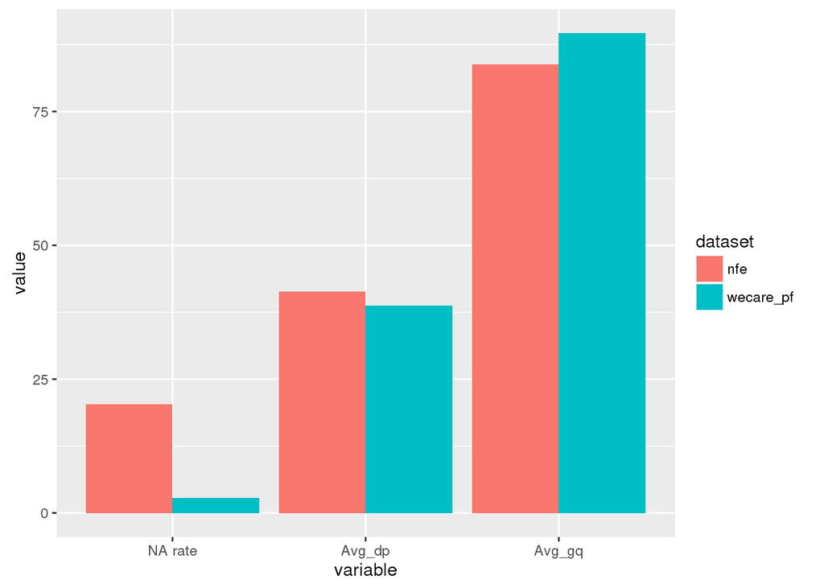

```r
# Summary plot
qc_summary.df <- as.data.frame(qc_summary)
qc_summary.df <- cbind(rownames(qc_summary.df), qc_summary.df)
colnames(qc_summary.df)[1] <- "dataset"

qc_summary.m <- melt(qc_summary.df, id.vars="dataset")
ggplot(qc_summary.m, aes(variable, value)) +
  geom_bar(aes(fill = dataset), position = "dodge", stat="identity")
```

```r
# Clean-up
rm(gt_nfe.na, gt_wecare_pf.na, dp_nfe.na, dp_wecare_pf.na, dp_nfe.awg, dp_wecare_pf.awg,
   dp_nfe.gt.awg, dp_wecare_pf.gt.awg, gq_nfe.na, gq_wecare_pf.na, gq_nfe.awg,
   gq_wecare_pf.awg, gq_nfe.gt.awg, gq_wecare_pf.gt.awg, nfe_qc_summary,
   wecare_pf_qc_summary, qc_summary, qc_summary.df, qc_summary.m,
   dp_nfe.mx, gq_nfe.mx, dp_wecare_pf.mx, gq_wecare_pf.mx)
```

# data_summary

```r
ls()
```

```
## [1] "exac.df"                 "gt_nfe.mx"
## [3] "gt_wecare_pf.mx"         "interim_data_folder"
## [5] "kgen.df"                 "params"
## [7] "phenotypes_wecare_pf.df" "variants.df"
```

```r
dim(gt_wecare_pf.mx)
```

```
## [1] 279874    491
```

```r
class(gt_wecare_pf.mx)
```

```
## [1] "matrix"
```

```r
gt_wecare_pf.mx[1:5,1:5]
```

```
##              P1_A01 P1_A02 P1_A03 P1_A04 P1_A05
## Var000000002      0      0      0      0      0
## Var000000008      0      0     NA      0     NA
## Var000000009      0     NA     NA      0     NA
## Var000000012      0     NA     NA      0      0
## Var000000013      0     NA      0      0      0
```

```r
dim(gt_nfe.mx)
```

```
## [1] 279874    198
```

```r
class(gt_nfe.mx)
```

```
## [1] "matrix"
```

```r
gt_nfe.mx[1:5,1:5]
```

```
##              HG00097 HG00099 HG00100 HG00102 HG00106
## Var000000002       0       0      NA      NA       0
## Var000000008       0      NA       0       0       0
## Var000000009       0       0       0       0       0
## Var000000012       0       0      NA       0       0
## Var000000013       0       0      NA       0       0
```

```r
dim(phenotypes_wecare_pf.df)
```

```
## [1] 491  28
```

```r
str(phenotypes_wecare_pf.df)
```

```
## 'data.frame':    491 obs. of  28 variables:
##  $ wes_id        : chr  "P1_A01" "P1_A02" "P1_A03" "P1_A04" ...
##  $ gwas_id       : chr  "id203568" "id357807" "id325472" "id304354" ...
##  $ merged_id     : chr  "P1_A01_id203568" "P1_A02_id357807" "P1_A03_id325472" "P1_A04_id304354" ...
##  $ filter        : chr  "pass" "pass" "pass" "pass" ...
##  $ cc            : int  1 1 1 1 1 1 0 1 1 1 ...
##  $ setno         : int  203568 357807 325472 304354 222648 244843 276284 297810 310692 250898 ...
##  $ family_history: int  1 0 1 1 1 1 1 1 0 1 ...
##  $ age_dx        : int  49 35 32 33 44 28 28 38 32 35 ...
##  $ age_ref       : num  58 36 41 34 49 28 32 44 39 35 ...
##  $ rstime        : num  10.17 1.83 9.75 1.59 5.66 ...
##  $ eig1_gwas     : num  -0.00389 -0.00379 -0.01011 -0.01288 -0.01086 ...
##  $ eig2_gwas     : num  0.00266 0.00246 -0.0001 0.00595 0.01157 ...
##  $ eig3_gwas     : num  0.06803 0.05055 -0.00603 0.00747 0.00144 ...
##  $ stage         : num  1 2 2 1 1 1 2 1 1 2 ...
##  $ er            : num  NA 0 0 0 NA 1 1 1 0 1 ...
##  $ pr            : num  NA 0 0 NA NA 1 NA 1 0 0 ...
##  $ hist_cat      : chr  "lobular" "ductal" "medullary" "ductal" ...
##  $ hormone       : num  0 0 0 0 1 0 0 0 0 0 ...
##  $ chemo_cat     : chr  "no" "CMF" "Oth" "no" ...
##  $ br_xray       : int  1 1 0 0 1 0 0 0 0 1 ...
##  $ br_xray_dose  : num  1.6 0.83 0 0 0.77 0 0 0 0 1.1 ...
##  $ age_menarche  : num  9 13 10 12 10 13 12 11 12 11 ...
##  $ age_1st_ftp   : num  30 0 26 0 17 0 25 28 21 27 ...
##  $ age_menopause : num  -1 -1 -1 -1 -1 -1 -1 -1 -1 -1 ...
##  $ num_preg      : num  1 0 1 0 1 0 1 1 1 1 ...
##  $ bmi_age18     : num  20.8 22.5 23.6 18.6 19.9 ...
##  $ bmi_dx        : num  25.8 22.9 28.3 17.8 26.6 ...
##  $ bmi_ref       : num  33.3 22.9 33.1 17.8 29.8 ...
```

```r
phenotypes_wecare_pf.df[1:5,1:5]
```

```
##        wes_id  gwas_id       merged_id filter cc
## P1_A01 P1_A01 id203568 P1_A01_id203568   pass  1
## P1_A02 P1_A02 id357807 P1_A02_id357807   pass  1
## P1_A03 P1_A03 id325472 P1_A03_id325472   pass  1
## P1_A04 P1_A04 id304354 P1_A04_id304354   pass  1
## P1_A05 P1_A05 id222648 P1_A05_id222648   pass  1
```

```r
dim(variants.df)
```

```
## [1] 279874     23
```

```r
colnames(variants.df)
```

```
##  [1] "SplitVarID"         "SYMBOL"             "TYPE"
##  [4] "CHROM"              "POS"                "REF"
##  [7] "ALT"                "AC"                 "AF"
## [10] "AN"                 "Consequence"        "SIFT_call"
## [13] "SIFT_score"         "PolyPhen_call"      "PolyPhen_score"
## [16] "CLIN_SIG"           "cDNA_position"      "CDS_position"
## [19] "Codons"             "Protein_position"   "Amino_acids"
## [22] "Existing_variation" "Multiallelic"
```

```r
variants.df[1:5,1:5]
```

```
##                SplitVarID    SYMBOL  TYPE CHROM    POS
## Var000000002 Var000000002 LINC00115   SNP     1 762330
## Var000000008 Var000000008    SAMD11   SNP     1 871215
## Var000000009 Var000000009    SAMD11   SNP     1 871230
## Var000000012 Var000000012    SAMD11 INDEL     1 874778
## Var000000013 Var000000013    SAMD11   SNP     1 878664
```

```r
dim(kgen.df)
```

```
## [1] 279874      9
```

```r
colnames(kgen.df)
```

```
## [1] "SplitVarID"  "kgen.AC"     "kgen.AN"     "kgen.AF"     "kgen.AFR_AF"
## [6] "kgen.AMR_AF" "kgen.EAS_AF" "kgen.EUR_AF" "kgen.SAS_AF"
```

```r
kgen.df[1:5,1:5]
```

```
##                SplitVarID kgen.AC kgen.AN     kgen.AF kgen.AFR_AF
## Var000000002 Var000000002      NA      NA          NA          NA
## Var000000008 Var000000008      NA      NA          NA          NA
## Var000000009 Var000000009      NA      NA          NA          NA
## Var000000012 Var000000012      NA      NA          NA          NA
## Var000000013 Var000000013       2    5008 0.000399361           0
```

```r
dim(exac.df)
```

```
## [1] 279874     48
```

```r
colnames(exac.df)
```

```
##  [1] "SplitVarID"              "exac_non_TCGA.AF"
##  [3] "exac_non_TCGA.AC"        "exac_non_TCGA.AN"
##  [5] "exac_non_TCGA.AC_FEMALE" "exac_non_TCGA.AN_FEMALE"
##  [7] "exac_non_TCGA.AC_MALE"   "exac_non_TCGA.AN_MALE"
##  [9] "exac_non_TCGA.AC_Adj"    "exac_non_TCGA.AN_Adj"
## [11] "exac_non_TCGA.AC_Hom"    "exac_non_TCGA.AC_Het"
## [13] "exac_non_TCGA.AC_Hemi"   "exac_non_TCGA.AC_AFR"
## [15] "exac_non_TCGA.AN_AFR"    "exac_non_TCGA.Hom_AFR"
## [17] "exac_non_TCGA.Het_AFR"   "exac_non_TCGA.Hemi_AFR"
## [19] "exac_non_TCGA.AC_AMR"    "exac_non_TCGA.AN_AMR"
## [21] "exac_non_TCGA.Hom_AMR"   "exac_non_TCGA.Het_AMR"
## [23] "exac_non_TCGA.Hemi_AMR"  "exac_non_TCGA.AC_EAS"
## [25] "exac_non_TCGA.AN_EAS"    "exac_non_TCGA.Hom_EAS"
## [27] "exac_non_TCGA.Het_EAS"   "exac_non_TCGA.Hemi_EAS"
## [29] "exac_non_TCGA.AC_FIN"    "exac_non_TCGA.AN_FIN"
## [31] "exac_non_TCGA.Hom_FIN"   "exac_non_TCGA.Het_FIN"
## [33] "exac_non_TCGA.Hemi_FIN"  "exac_non_TCGA.AC_NFE"
## [35] "exac_non_TCGA.AN_NFE"    "exac_non_TCGA.Hom_NFE"
## [37] "exac_non_TCGA.Het_NFE"   "exac_non_TCGA.Hemi_NFE"
## [39] "exac_non_TCGA.AC_SAS"    "exac_non_TCGA.AN_SAS"
## [41] "exac_non_TCGA.Hom_SAS"   "exac_non_TCGA.Het_SAS"
## [43] "exac_non_TCGA.Hemi_SAS"  "exac_non_TCGA.AC_OTH"
## [45] "exac_non_TCGA.AN_OTH"    "exac_non_TCGA.Hom_OTH"
## [47] "exac_non_TCGA.Het_OTH"   "exac_non_TCGA.Hemi_OTH"
```

```r
exac.df[1:5,1:5]
```

```
##                SplitVarID exac_non_TCGA.AF exac_non_TCGA.AC
## Var000000002 Var000000002        0.0120000              175
## Var000000008 Var000000008               NA               NA
## Var000000009 Var000000009               NA               NA
## Var000000012 Var000000012               NA               NA
## Var000000013 Var000000013        0.0005838               62
##              exac_non_TCGA.AN exac_non_TCGA.AC_FEMALE
## Var000000002            14012                      59
## Var000000008               NA                    1553
## Var000000009               NA                      NA
## Var000000012               NA                      NA
## Var000000013           106198                      17
```

```r
# Check consistency of rownames and colnames
sum(colnames(gt_wecare_pf.mx) != rownames(phenotypes_wecare_pf.df))
```

```
## [1] 0
```

```r
sum(rownames(gt_wecare_pf.mx) != rownames(gt_nfe.mx))
```

```
## [1] 0
```

```r
sum(rownames(gt_wecare_pf.mx) != rownames(variants.df))
```

```
## [1] 0
```

```r
sum(rownames(gt_wecare_pf.mx) != rownames(kgen.df))
```

```
## [1] 0
```

```r
sum(rownames(gt_wecare_pf.mx) != rownames(exac.df))
```

```
## [1] 0
```

# save_data

```r
save.image(paste(interim_data_folder, "s03_update_phenotypes.RData", sep="/"))
```

# final_section

```r
ls()
```

```
## [1] "exac.df"                 "gt_nfe.mx"
## [3] "gt_wecare_pf.mx"         "interim_data_folder"
## [5] "kgen.df"                 "params"
## [7] "phenotypes_wecare_pf.df" "variants.df"
```

```r
Sys.time()
```

```
## [1] "2016-12-11 20:47:48 GMT"
```